# Exploring Music Listeners Around the World

10/14/2016

## Introduction

- As the world becomes increasingly globalized, it is crucial to understand other cultures as much as possible.
- In NYC, it is clear we do that by trying the world's finest cuisine.
- But what about connecting through music?

## Goal

*Find artists popular in different countries but relatively unknown to the rest of the world.*

## Data

Data on last.fm users were scraped to create two data sets:

- Data Set 1: User listening history for 1000 users
- Data Set 2: User favorite artist plays for 360k users

## Question One

*How do users listen to artists?*

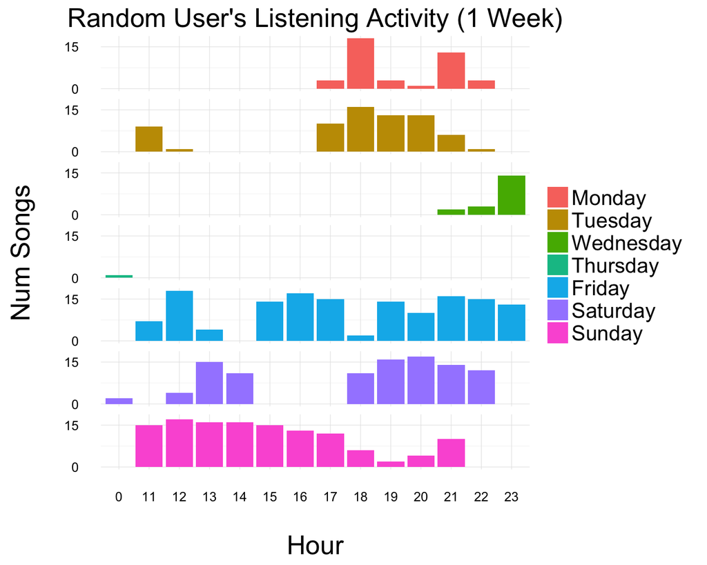

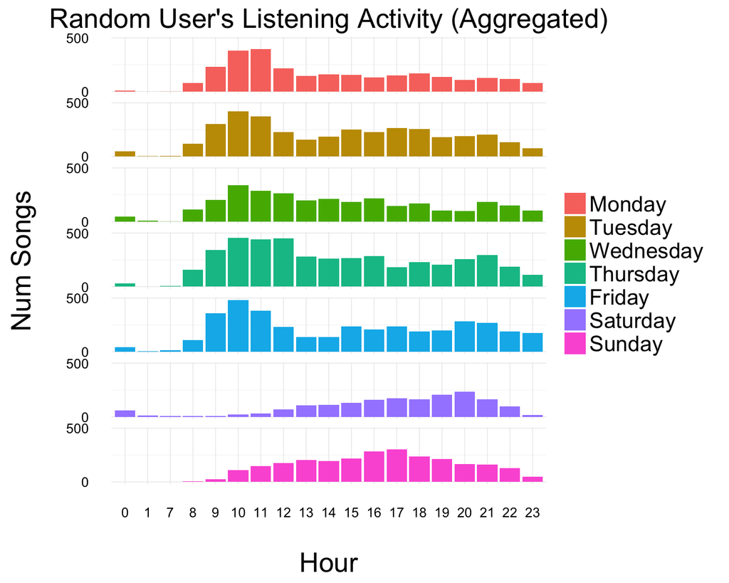

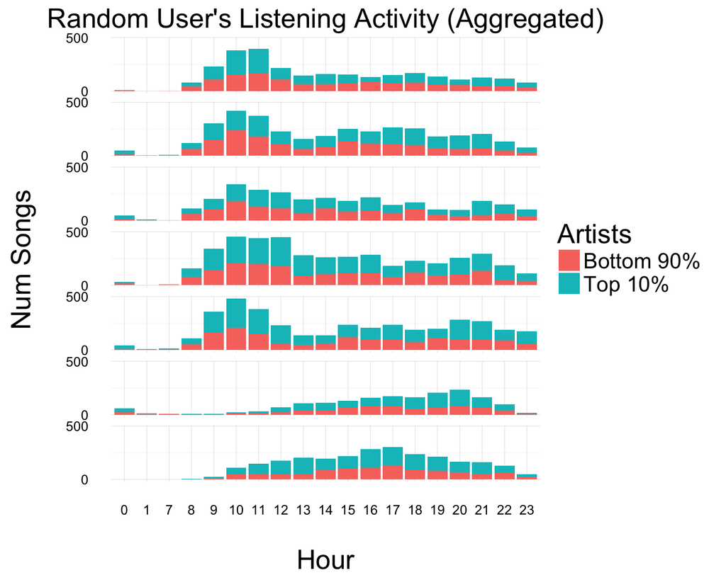

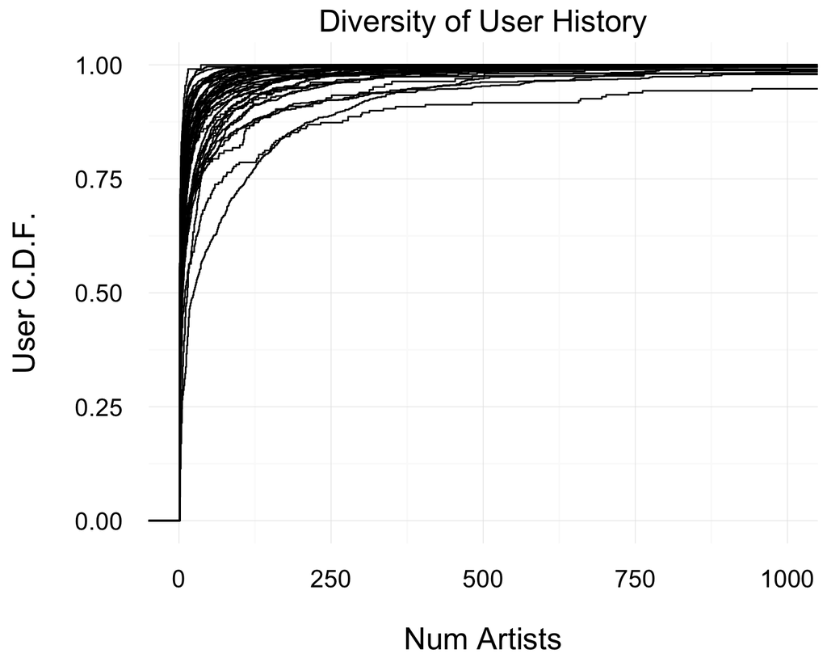

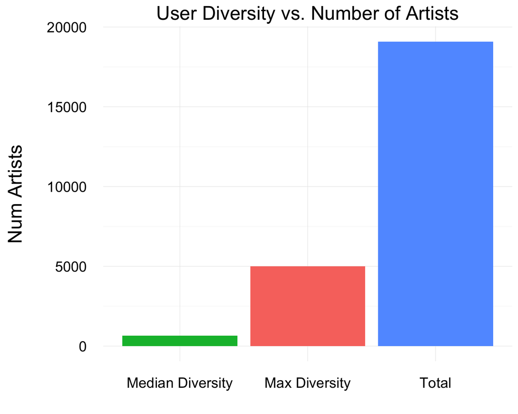

## Question Two

*Where do users listen to artists?*

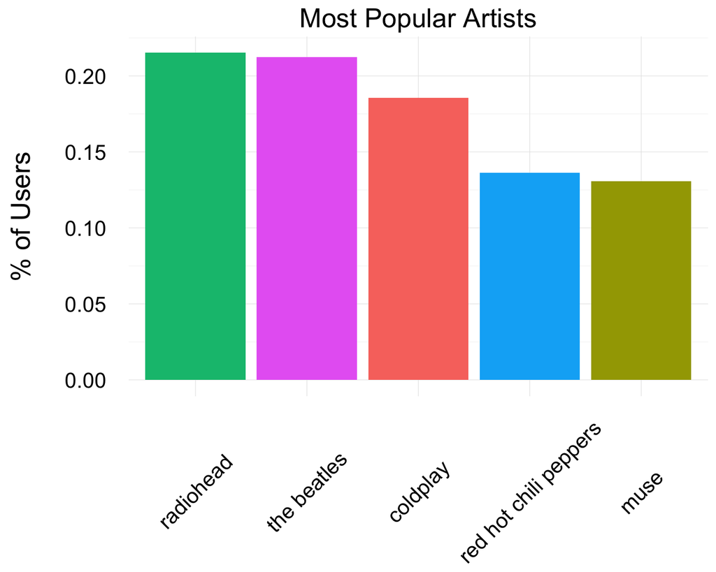

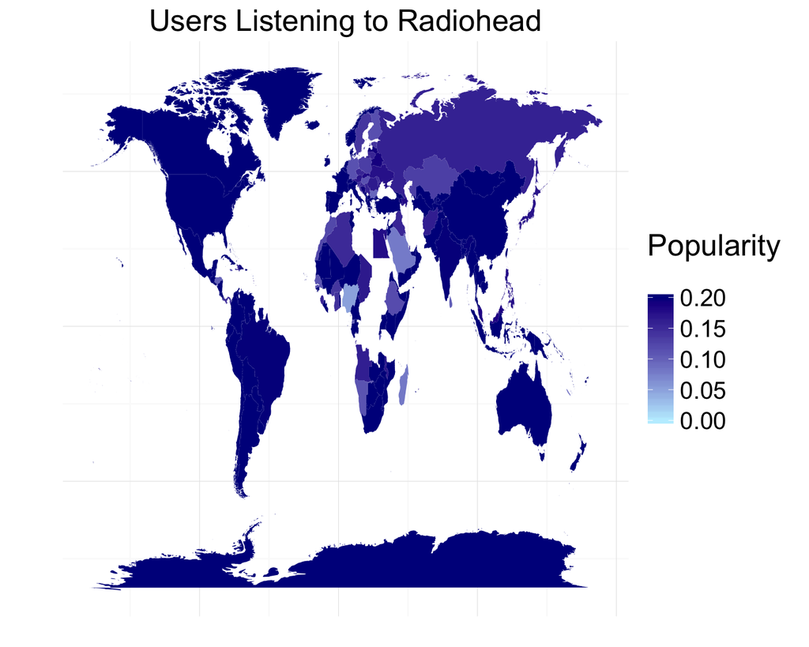

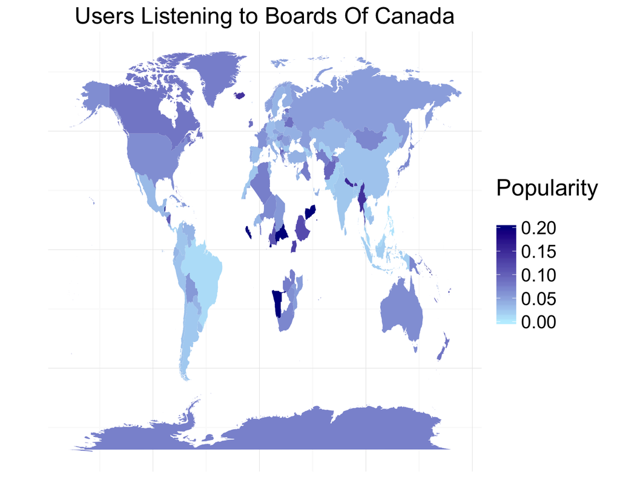

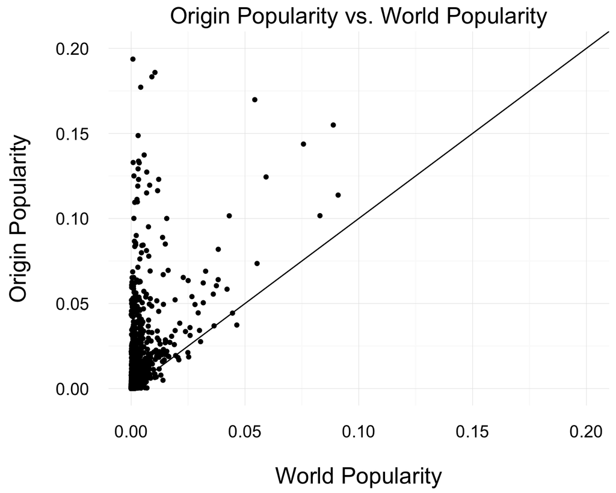

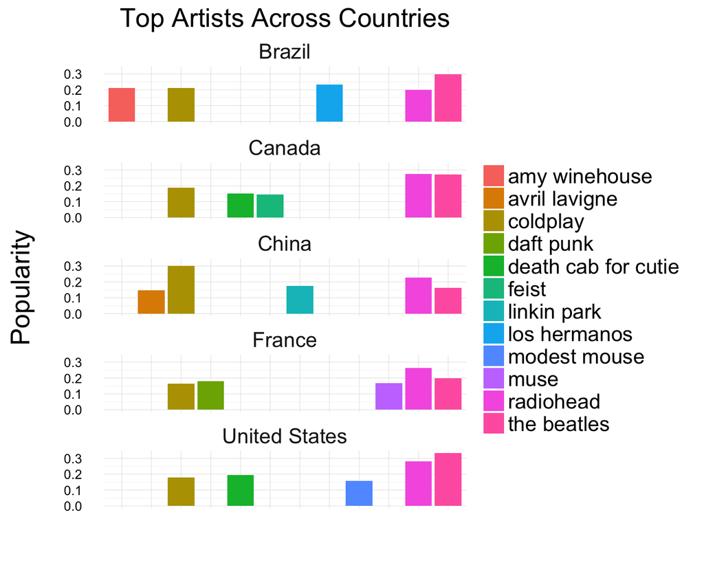

## Question Three

*How to find artists popular in a country unknown to the rest of the world?*

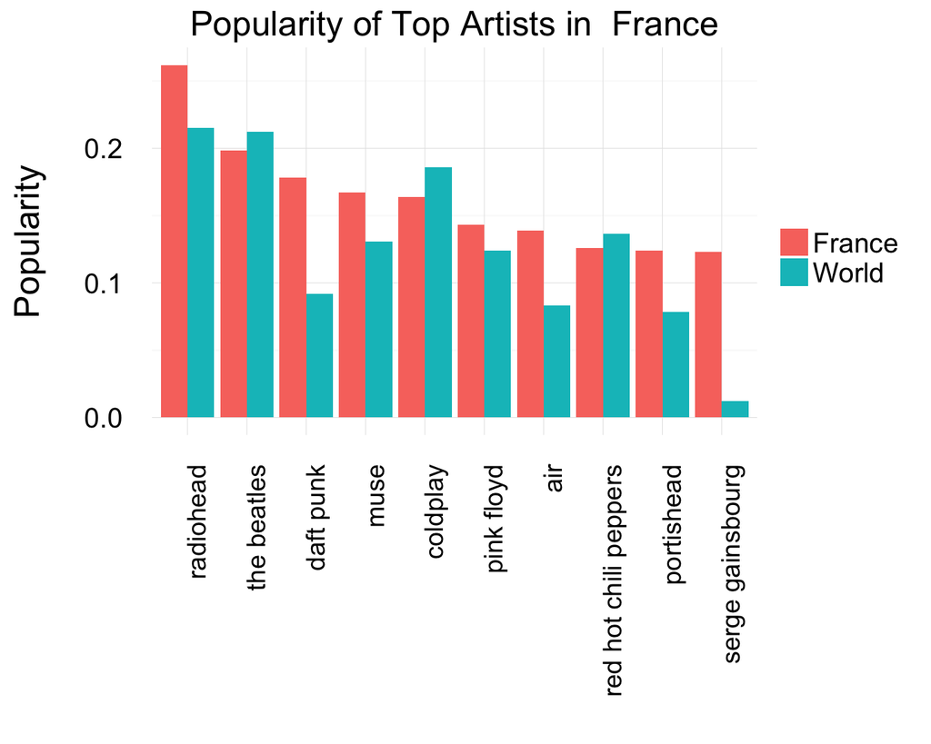

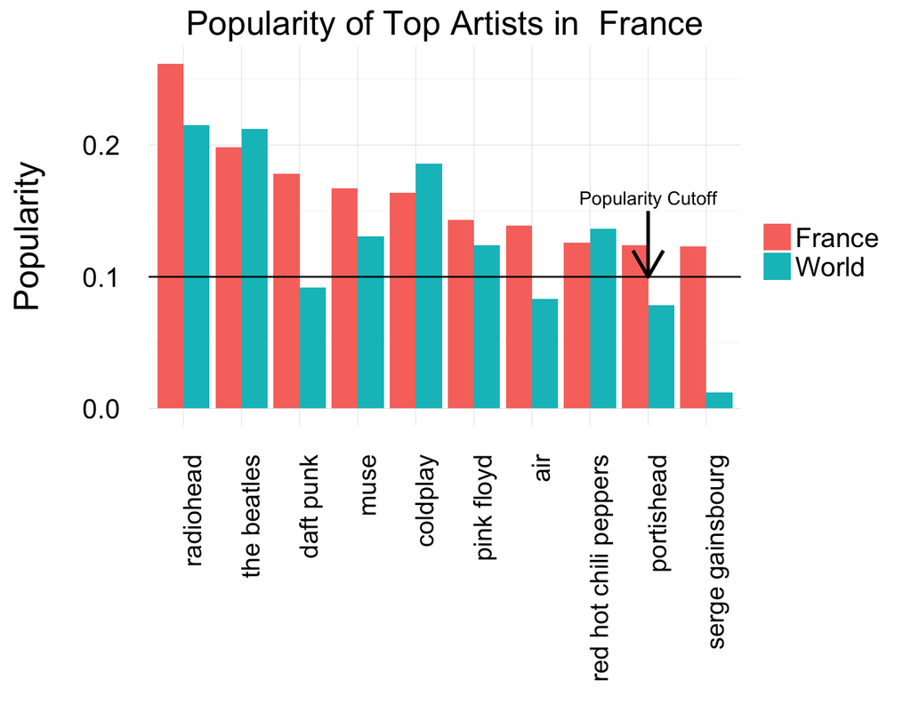

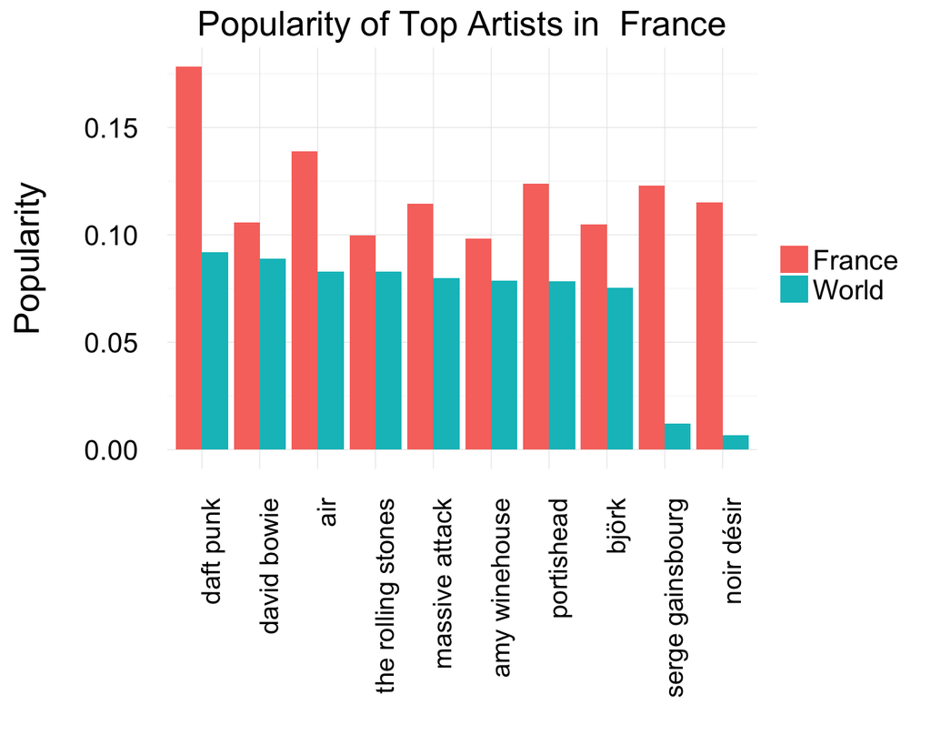

## How to Find Unknown Aritsts

*net popularity = country popularity - world popularity*

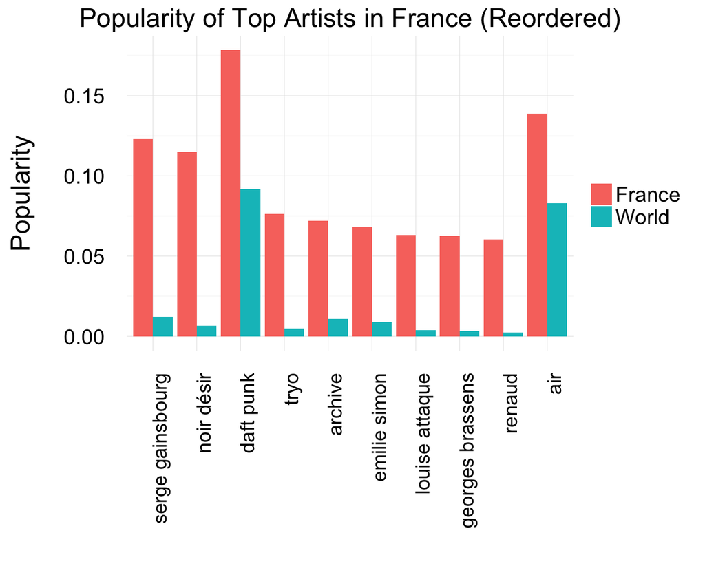

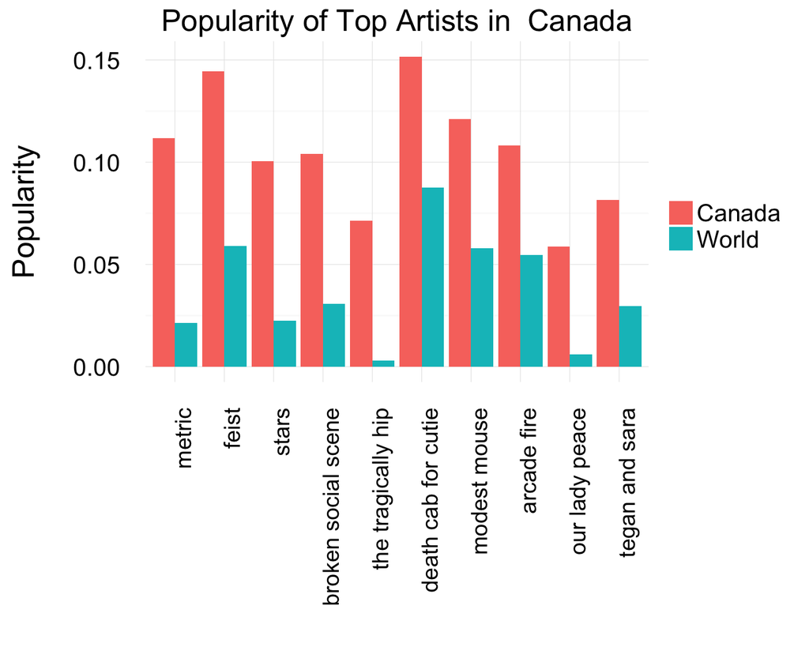

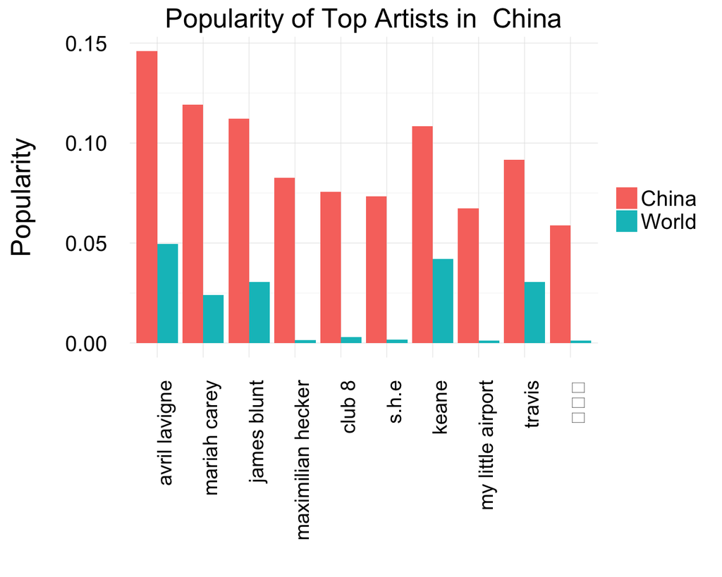

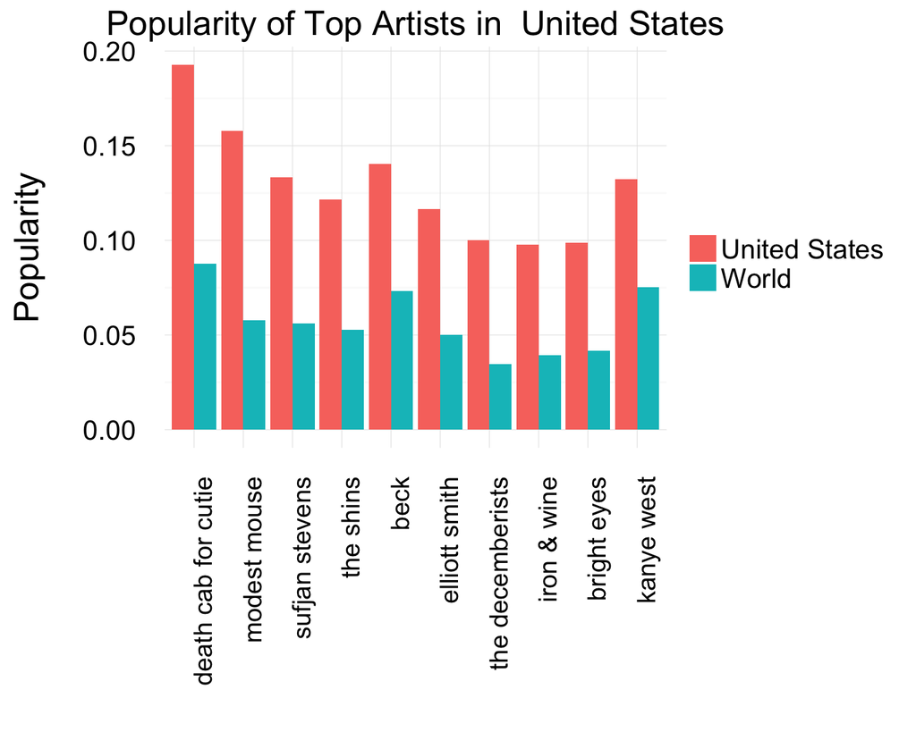

## Coming Soon

A youtube playlist with top artists from each country!

## Future Work

- Look up when artists started to discover new bands
- Investigate why artists become popular in certain countries
- Ineractive map to play music popular in a country
  - (Shiny Project???)

## References

- Last.fm Data
  - [Music Recommendation Datasets for Research](http://www.dtic.upf.edu/~ocelma/MusicRecommendationDataset/lastfm-1K.html)
- Artist Location Data
  - [Million Song Dataset](http://labrosa.ee.columbia.edu/millionsong/)